# CH7 Non-linear models

Regan Cross

2019-03-02

This tutorial is based on Chapter 7 “Moving Beyond Linearity”. This tutorial covers polynomial regression, step functions, regression splines, smoothing splines, local regression, and generalized additive models.

## Polynomial Regression

Linear model with predictors xi, xi<sup>2</sup>, xi<sup>3</sup>, …, xi<sup>d</sup>. Note: Models with too large a value of d can be overly flexible and take on strange shapes (i.e. d > 4).

Example: We’ll look at how habitat heterogeneity affects the variation in wingedness of seeds for a dune plant. We quantified the % of suitable habitat in patches surrounding parent plants, then quantified the variation in wingedness of that plant’s seeds.

```r
library(tidyverse)
dat <- read.csv("anthshab.csv")
head(dat)
```

```
##   site     lat        WI    residWI    sd_WI sdresidWI sitesd_hh
## 1  CTP 32.9290  6.794872  0.9930645 3.077094  2.522343  25.52172
## 2  CSO 33.3808 11.285714  0.9040960 2.799481  2.607573  26.92832
## 3  CHB 33.6325  9.888889  2.0048870 2.007299  1.780806  40.39179
## 4  CSB 34.2679  6.812500  0.6404993 2.932684  2.348450  40.26313
## 5  CCO 34.4120  8.688889 -0.3062549 3.168028  2.459669  32.88258
## 6  CMO 35.3658 11.166667  1.6071597 3.751387  3.259889  33.04545
##   sitemean_pp sitesd_pp meanMhab meanSDhab
## 1    58.33333  16.14393 14.25000  22.03733
## 2    66.07143  19.97993 12.71429  20.99533
## 3    80.62500  12.49475 48.62500  41.37972
## 4    79.00000  15.83260 55.75000  32.01856
## 5    58.83333  19.32950 38.83333  31.10342
## 6    55.00000  20.56256 57.83667  27.40220
```

```r
summary(dat)
```

```
##       site        lat              WI            residWI
##  CAS    :1   Min.   :32.93   Min.   : 5.392   Min.   :-1.99505
##  CCO    :1   1st Qu.:34.30   1st Qu.: 6.799   1st Qu.:-0.98719
##  CDB    :1   Median :36.77   Median : 8.730   Median :-0.17666
##  CGB    :1   Mean   :37.00   Mean   : 8.741   Mean   : 0.04023
##  CHB    :1   3rd Qu.:38.82   3rd Qu.:11.138   3rd Qu.: 0.97082
##  CLR    :1   Max.   :42.74   Max.   :11.905   Max.   : 2.00489
##  (Other):8
##      sd_WI         sdresidWI       sitesd_hh      sitemean_pp
##  Min.   :1.681   Min.   :1.630   Min.   :22.68   Min.   :55.00
##  1st Qu.:2.021   1st Qu.:1.853   1st Qu.:32.92   1st Qu.:69.01
##  Median :2.905   Median :2.404   Median :35.94   Median :80.55
##  Mean   :2.901   Mean   :2.439   Mean   :35.71   Mean   :76.56
##  3rd Qu.:3.268   3rd Qu.:2.607   3rd Qu.:40.36   3rd Qu.:81.85
##  Max.   :4.847   Max.   :3.767   Max.   :46.00   Max.   :96.86
##
##    sitesd_pp         meanMhab       meanSDhab
##  Min.   : 6.677   Min.   :12.71   Min.   :20.32
##  1st Qu.:12.637   1st Qu.:35.78   1st Qu.:27.89
##  Median :14.850   Median :47.27   Median :31.85
##  Mean   :15.017   Mean   :47.21   Mean   :32.98
##  3rd Qu.:18.615   3rd Qu.:57.62   3rd Qu.:40.66
##  Max.   :20.563   Max.   :85.00   Max.   :46.23
##
```

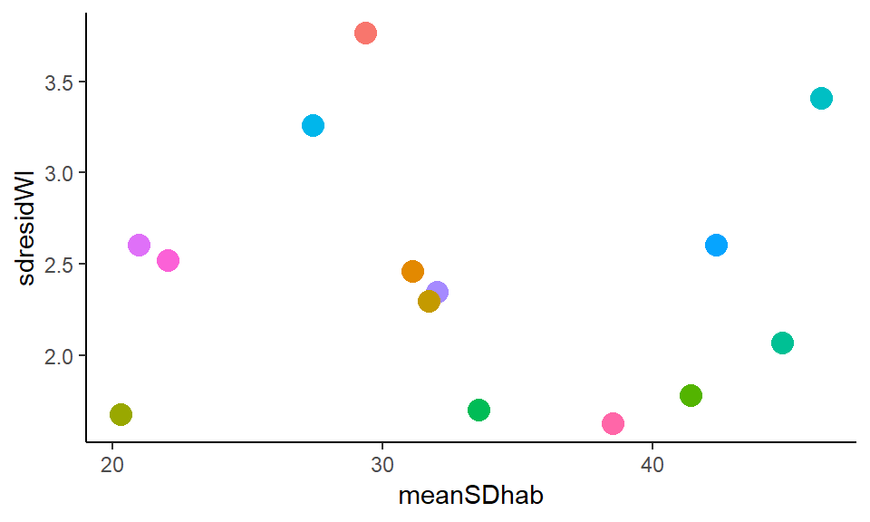

```r
# we are going to look at the mean plant standard deviation in habitat patch suitability, and the standard deviation of the residual wing index.
ggplot(dat, aes(x = meanSDhab, y = sdresidWI, colour=site)) +
  geom_point(size = 4) +
  theme(legend.position = "none") +
  theme(panel.background = element_blank(), axis.line = element_line(colour = "black"))
```

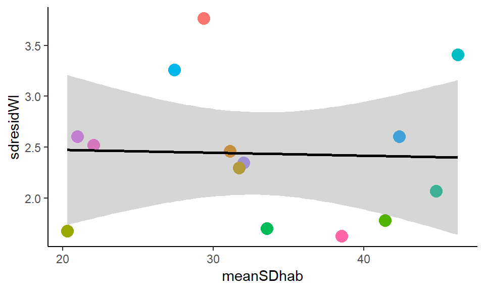

```r
# let's see if there is maybe a linear relationship
ggplot(dat, aes(x = meanSDhab, y = sdresidWI, colour=site)) +
  geom_point(size = 4) +
  geom_smooth(method = "lm", colour = "black") +
  theme(legend.position = "none") +
  theme(panel.background = element_blank(), axis.line = element_line(colour = "black"))
```

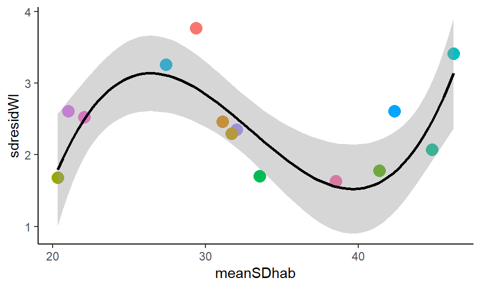

```r
# looks like nope

# perhaps it could be a cubic polynomial
ggplot(dat, aes(x = meanSDhab, y = sdresidWI, colour=site)) +
  geom_point(size = 4) +
  geom_smooth(method = "lm", colour = "black", formula = y ~ x + I((x-mean(x))^2) + I((x-mean(x))^3)) +
  theme(legend.position = "none") +
  theme(panel.background = element_blank(), axis.line = element_line(colour = "black"))
```

```r
# looks promising, let's test it
```

```r
mod3 <- lm(sdresidWI ~ meanSDhab + I(meanSDhab^2) + I(meanSDhab^3), data=dat)
summary(mod3)
```

```
##
## Call:
## lm(formula = sdresidWI ~ meanSDhab + I(meanSDhab^2) + I(meanSDhab^3),
##     data = dat)
##
## Residuals:
##      Min       1Q   Median       3Q      Max
## -0.56276 -0.25983 -0.03872  0.10269  0.82081
##
## Coefficients:
##                  Estimate Std. Error t value Pr(>|t|)
## (Intercept)    -4.067e+01  1.098e+01  -3.702  0.00409 **
## meanSDhab       4.314e+00  1.083e+00   3.984  0.00258 **
## I(meanSDhab^2) -1.374e-01  3.418e-02  -4.020  0.00244 **
## I(meanSDhab^3)  1.400e-03  3.468e-04   4.036  0.00238 **
## ---
## Signif. codes:  0 '***' 0.001 '**' 0.01 '*' 0.05 '.' 0.1 ' ' 1
##
## Residual standard error: 0.4699 on 10 degrees of freedom
## Multiple R-squared:  0.6206, Adjusted R-squared:  0.5067
## F-statistic: 5.451 on 3 and 10 DF,  p-value: 0.01759
```

All terms in the cubic polynomial regression are significant, and the model explains 62% of the variation in the data.

```r
# alternatively we can write polynomial models like this (for brevity)
mod3a <- lm(sdresidWI ~ poly(meanSDhab, 3), data=dat)
summary(mod3a)
```

```
##
## Call:
## lm(formula = sdresidWI ~ poly(meanSDhab, 3), data = dat)
##
## Residuals:
##      Min       1Q   Median       3Q      Max
## -0.56276 -0.25983 -0.03872  0.10269  0.82081
##
## Coefficients:
##                     Estimate Std. Error t value Pr(>|t|)
## (Intercept)          2.43851    0.12558  19.418 2.86e-09 ***
## poly(meanSDhab, 3)1 -0.08907    0.46988  -0.190  0.85344
## poly(meanSDhab, 3)2  0.07826    0.46988   0.167  0.87105
## poly(meanSDhab, 3)3  1.89652    0.46988   4.036  0.00238 **
## ---
## Signif. codes:  0 '***' 0.001 '**' 0.01 '*' 0.05 '.' 0.1 ' ' 1
##
## Residual standard error: 0.4699 on 10 degrees of freedom
## Multiple R-squared:  0.6206, Adjusted R-squared:  0.5067
## F-statistic: 5.451 on 3 and 10 DF,  p-value: 0.01759
```

```r
# and we get the same overall p value and R^2^'s, but the p values for the linear and quadratic components are no longer significant; this is because in the original mod3 the linear, quadratic and cubic parameters are allowed to be correlated because they are the direct estimates of the individual effects without accounting for their correlation
# whereas in the mod3a with the poly() command, the model produces orthogonal polynomials and so they are not allowed to be correlated, and it shows that only the cubic function is really significant

# let's look at the coefficients
coef(summary(mod3a))
```

```
##                        Estimate Std. Error    t value     Pr(>|t|)
## (Intercept)          2.43851464  0.1255811 19.4178530 2.864025e-09
## poly(meanSDhab, 3)1 -0.08907285  0.4698813 -0.1895646 8.534428e-01
## poly(meanSDhab, 3)2  0.07825540  0.4698813  0.1665429 8.710490e-01
## poly(meanSDhab, 3)3  1.89652144  0.4698813  4.0361712 2.375806e-03
```

```r
coef(summary(mod3))
```

```
##                     Estimate   Std. Error   t value    Pr(>|t|)
## (Intercept)    -40.666836667 1.098466e+01 -3.702148 0.004093966
## meanSDhab        4.313517697 1.082718e+00  3.983971 0.002584333
## I(meanSDhab^2)  -0.137421423 3.418481e-02 -4.019956 0.002438625
## I(meanSDhab^3)   0.001399828 3.468207e-04  4.036171 0.002375806
```

```r
# they differ because in 3a the columns are orthogonal polynomials so each column is a linear combination of all the variables
# whereas in 3 they are just the direct coefficients of each variable individually

# we can also obtain the direct (correlated) effects using the poly() command if we include raw=TRUE
mod3b <- lm(sdresidWI ~ poly(meanSDhab, 3, raw=TRUE), data=dat)
summary(mod3b) # same results as mod3
```

```
##
## Call:
## lm(formula = sdresidWI ~ poly(meanSDhab, 3, raw = TRUE), data = dat)
##
## Residuals:
##      Min       1Q   Median       3Q      Max
## -0.56276 -0.25983 -0.03872  0.10269  0.82081
##
## Coefficients:
##                                   Estimate Std. Error t value Pr(>|t|)
## (Intercept)                     -4.067e+01  1.098e+01  -3.702  0.00409 **
## poly(meanSDhab, 3, raw = TRUE)1  4.314e+00  1.083e+00   3.984  0.00258 **
## poly(meanSDhab, 3, raw = TRUE)2 -1.374e-01  3.418e-02  -4.020  0.00244 **
## poly(meanSDhab, 3, raw = TRUE)3  1.400e-03  3.468e-04   4.036  0.00238 **
## ---
## Signif. codes:  0 '***' 0.001 '**' 0.01 '*' 0.05 '.' 0.1 ' ' 1
##
## Residual standard error: 0.4699 on 10 degrees of freedom
## Multiple R-squared:  0.6206, Adjusted R-squared:  0.5067
## F-statistic: 5.451 on 3 and 10 DF,  p-value: 0.01759
```

```r
coef(summary(mod3b))
```

```
##                                      Estimate   Std. Error   t value
## (Intercept)                     -40.666836667 1.098466e+01 -3.702148
## poly(meanSDhab, 3, raw = TRUE)1   4.313517697 1.082718e+00  3.983971
## poly(meanSDhab, 3, raw = TRUE)2  -0.137421423 3.418481e-02 -4.019956
## poly(meanSDhab, 3, raw = TRUE)3   0.001399828 3.468207e-04  4.036171
##                                    Pr(>|t|)
## (Intercept)                     0.004093966
## poly(meanSDhab, 3, raw = TRUE)1 0.002584333
## poly(meanSDhab, 3, raw = TRUE)2 0.002438625
## poly(meanSDhab, 3, raw = TRUE)3 0.002375806
```

Note on using raw vs orthogonal polynomials: If we use the correlated (raw=TRUE) covariates, our ability to determine which are important (and their effect sizes) deteriorates, and we might get much larger SEs (see that SEs are larger in coefs from mod3b than mod3a for intercept and linear component). So, it might be better to use orthogonalized polynomials to see the correct effect sizes and get more stable estimates. One drawback of this is that we lose interpretability… the meaning of the coefficients is less clear.

So the cubic polynomial is highly significant, let’s see if its the best fit polynomial regression for this data.

```r
fit.1= lm(sdresidWI ~ meanSDhab, data=dat)
fit.2= lm(sdresidWI ~ poly(meanSDhab, 2), data=dat)
fit.3= lm(sdresidWI ~ poly(meanSDhab, 3), data=dat)
fit.4= lm(sdresidWI ~ poly(meanSDhab, 4), data=dat)
fit.5= lm(sdresidWI ~ poly(meanSDhab, 5), data=dat)
anova(fit.1, fit.2, fit.3, fit.4, fit.5)
```

```
## Analysis of Variance Table
##
## Model 1: sdresidWI ~ meanSDhab
## Model 2: sdresidWI ~ poly(meanSDhab, 2)
## Model 3: sdresidWI ~ poly(meanSDhab, 3)
## Model 4: sdresidWI ~ poly(meanSDhab, 4)
## Model 5: sdresidWI ~ poly(meanSDhab, 5)
##   Res.Df    RSS Df Sum of Sq       F   Pr(>F)
## 1     12 5.8108
## 2     11 5.8047  1    0.0061  0.0280 0.871346
## 3     10 2.2079  1    3.5968 16.4235 0.003671 **
## 4      9 1.7620  1    0.4459  2.0358 0.191469
## 5      8 1.7520  1    0.0100  0.0457 0.836113
## ---
## Signif. codes:  0 '***' 0.001 '**' 0.01 '*' 0.05 '.' 0.1 ' ' 1
```

The cubic model is clearly the best fit, and the rest of the models are not good fits. Alternatively, you can use cross-validation to choose the best polynomial degree. (as in Chapter 5)

## Step functions

Cut range of variable into K distinct regions to produce a qualitative variable. Avoid imposing a global structure by breaking range of X into bins and fitting a different constant to each bin - essentially converting a continuous variable into an ordered categorical variable (using dummy indicator variables).

Here, we’ll use the Wage data in the ISLR package, to see whether people’s age affects what wage category they fall into.

```r
library(ISLR)
# cut the data into K = 4 groups
head(Wage)
```

```
##        year age           maritl     race       education
## 231655 2006  18 1. Never Married 1. White    1. < HS Grad
## 86582  2004  24 1. Never Married 1. White 4. College Grad
## 161300 2003  45       2. Married 1. White 3. Some College
## 155159 2003  43       2. Married 3. Asian 4. College Grad
## 11443  2005  50      4. Divorced 1. White      2. HS Grad
## 376662 2008  54       2. Married 1. White 4. College Grad
##                    region       jobclass         health health_ins
## 231655 2. Middle Atlantic  1. Industrial      1. <=Good      2. No
## 86582  2. Middle Atlantic 2. Information 2. >=Very Good      2. No
## 161300 2. Middle Atlantic  1. Industrial      1. <=Good     1. Yes
## 155159 2. Middle Atlantic 2. Information 2. >=Very Good     1. Yes
## 11443  2. Middle Atlantic 2. Information      1. <=Good     1. Yes
## 376662 2. Middle Atlantic 2. Information 2. >=Very Good     1. Yes
##         logwage      wage
## 231655 4.318063  75.04315
## 86582  4.255273  70.47602
## 161300 4.875061 130.98218
## 155159 5.041393 154.68529
## 11443  4.318063  75.04315
## 376662 4.845098 127.11574
```

```r
table(cut(Wage$age, 4))  # automatically cuts at 33.5, 49, 64.5 years old
```

```
##
## (17.9,33.5]   (33.5,49]   (49,64.5] (64.5,80.1]
##         750        1399         779          72
```

```r
table(cut(Wage$age, breaks=c(17, 33, 42, 51, 81))) # can manually specify the breaks as well
```

```
##
## (17,33] (33,42] (42,51] (51,81]
##     750     759     817     674
```

```r
mod <- lm(wage ~ cut(age, 4), data=Wage)
summary(mod)
```

```
##
## Call:
## lm(formula = wage ~ cut(age, 4), data = Wage)
##
## Residuals:
##     Min      1Q  Median      3Q     Max
## -98.126 -24.803  -6.177  16.493 200.519
##
## Coefficients:
##                        Estimate Std. Error t value Pr(>|t|)
## (Intercept)              94.158      1.476  63.790   <2e-16 ***
## cut(age, 4)(33.5,49]     24.053      1.829  13.148   <2e-16 ***
## cut(age, 4)(49,64.5]     23.665      2.068  11.443   <2e-16 ***
## cut(age, 4)(64.5,80.1]    7.641      4.987   1.532    0.126
## ---
## Signif. codes:  0 '***' 0.001 '**' 0.01 '*' 0.05 '.' 0.1 ' ' 1
##
## Residual standard error: 40.42 on 2996 degrees of freedom
## Multiple R-squared:  0.0625, Adjusted R-squared:  0.06156
## F-statistic: 66.58 on 3 and 2996 DF,  p-value: < 2.2e-16
```

```r
coef(summary(mod))
```

```
##                         Estimate Std. Error   t value     Pr(>|t|)
## (Intercept)            94.158392   1.476069 63.789970 0.000000e+00
## cut(age, 4)(33.5,49]   24.053491   1.829431 13.148074 1.982315e-38
## cut(age, 4)(49,64.5]   23.664559   2.067958 11.443444 1.040750e-29
## cut(age, 4)(64.5,80.1]  7.640592   4.987424  1.531972 1.256350e-01
```

Average salary for first age group (<33.5) is $94 159, then the estimates are additive for the rest of the age groups. The last age group is not significantly higher than the first age group (p = 0.126). This step function on age explains 6.25% of the variation in the wage data.

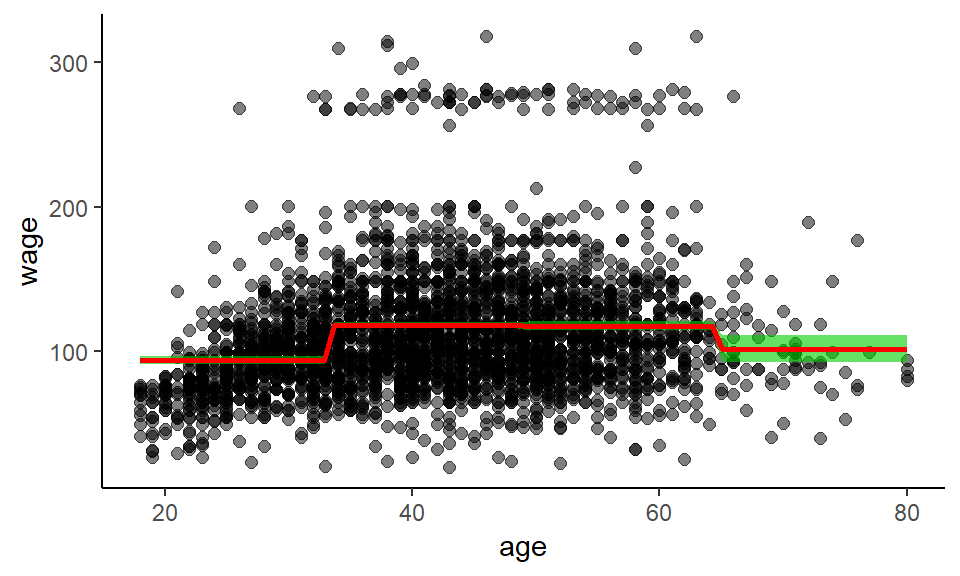

```r
ggplot(Wage, aes(x = age, y = wage)) +
  geom_point(size = 2, alpha= 0.5) +
  geom_smooth(method = "lm", colour = "red", alpha=0.6, fill="green3", formula = y ~ cut(x, 4)) +
  theme(legend.position = "none") +
  theme(panel.background = element_blank(), axis.line = element_line(colour = "black"))
```

We can see that the SE around the last segment of the line is wider because the sample size is so much smaller in this group (n = 72). The segments are broken up based on even spacing throughout the range of X.

We can also try with specified break points to get more even sample sizes within each group.

```r
mod <- lm(wage ~ cut(age, breaks=c(17, 33, 42, 51, 81)), data=Wage)
summary(mod)
```

```
##
## Call:
## lm(formula = wage ~ cut(age, breaks = c(17, 33, 42, 51, 81)),
##     data = Wage)
##
## Residuals:
##     Min      1Q  Median      3Q     Max
## -99.103 -25.116  -6.177  16.661 201.771
##
## Coefficients:
##                                                 Estimate Std. Error
## (Intercept)                                       94.158      1.478
## cut(age, breaks = c(17, 33, 42, 51, 81))(33,42]   22.502      2.084
## cut(age, breaks = c(17, 33, 42, 51, 81))(42,51]   25.030      2.047
## cut(age, breaks = c(17, 33, 42, 51, 81))(51,81]   22.413      2.149
##                                                 t value Pr(>|t|)
## (Intercept)                                       63.69   <2e-16 ***
## cut(age, breaks = c(17, 33, 42, 51, 81))(33,42]   10.79   <2e-16 ***
## cut(age, breaks = c(17, 33, 42, 51, 81))(42,51]   12.23   <2e-16 ***
## cut(age, breaks = c(17, 33, 42, 51, 81))(51,81]   10.43   <2e-16 ***
## ---
## Signif. codes:  0 '***' 0.001 '**' 0.01 '*' 0.05 '.' 0.1 ' ' 1
##
## Residual standard error: 40.49 on 2996 degrees of freedom
## Multiple R-squared:  0.05961,    Adjusted R-squared:  0.05867
## F-statistic:  63.3 on 3 and 2996 DF,  p-value: < 2.2e-16
```

```r
coef(summary(mod))
```

```
##                                                 Estimate Std. Error
## (Intercept)                                     94.15839   1.478343
## cut(age, breaks = c(17, 33, 42, 51, 81))(33,42] 22.50242   2.084485
## cut(age, breaks = c(17, 33, 42, 51, 81))(42,51] 25.03027   2.047381
## cut(age, breaks = c(17, 33, 42, 51, 81))(51,81] 22.41332   2.148821
##                                                  t value     Pr(>|t|)
## (Intercept)                                     63.69186 0.000000e+00
## cut(age, breaks = c(17, 33, 42, 51, 81))(33,42] 10.79519 1.115745e-26
## cut(age, breaks = c(17, 33, 42, 51, 81))(42,51] 12.22551 1.414032e-33
## cut(age, breaks = c(17, 33, 42, 51, 81))(51,81] 10.43052 4.803648e-25
```

For this, all of the subsequent groups have significantly higher salaries than the youngest group.

Are all groups significantly different from each other?

```r
aov <- aov(mod)
TukeyHSD(aov)
```

```
##   Tukey multiple comparisons of means
##     95% family-wise confidence level
##
## Fit: aov(formula = mod)
##
## $`cut(age, breaks = c(17, 33, 42, 51, 81))`
##                        diff       lwr       upr     p adj
## (33,42]-(17,33] 22.50241796 17.144302 27.860533 0.0000000
## (42,51]-(17,33] 25.03027283 19.767534 30.293012 0.0000000
## (51,81]-(17,33] 22.41332399 16.889836 27.936812 0.0000000
## (42,51]-(33,42]  2.52785487 -2.718591  7.774300 0.6023231
## (51,81]-(33,42] -0.08909398 -5.597060  5.418872 0.9999742
## (51,81]-(42,51] -2.61694884 -8.032178  2.798280 0.5999653
```

Nope, the last three groups are not significantly different from each other, which we can see when we plot the relationsip (below).

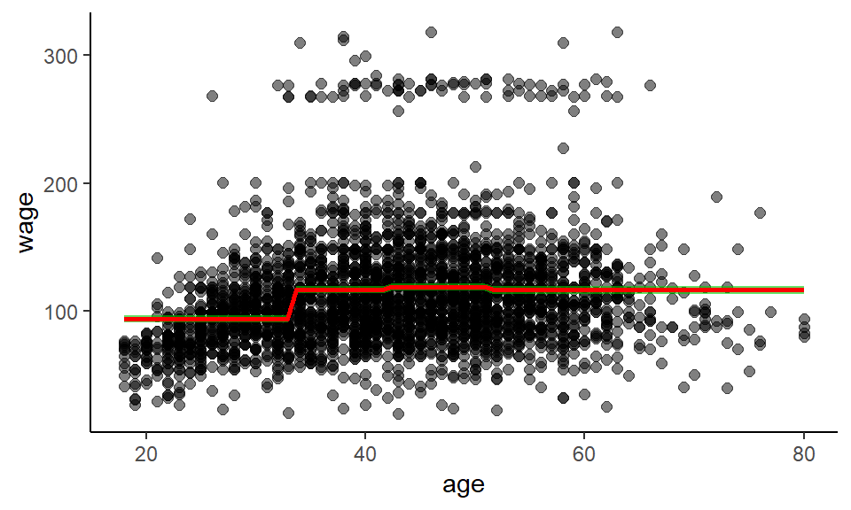

```r
ggplot(Wage, aes(x = age, y = wage)) +
  geom_point(size = 2, alpha= 0.5) +
  geom_smooth(method = "lm", colour = "red",  alpha=0.6, fill="green3", formula = y ~ cut(x, breaks=c(17, 33, 42, 51, 81))) +
  theme(legend.position = "none") +
  theme(panel.background = element_blank(), axis.line = element_line(colour = "black"))
```